# Churn de clientes en una empresa de telecomunicaciones.

Raul Vila

#### El objetivo del presente trabajo es detectar que clientes son mas propensos a irse de la compania.

##### Cargar los datasets y construir un único tablón analítico con todas las variables que consideremos necesarias para cada una de las cosechas que queremos analizar.

```python
from sklearn.datasets import make_classification
from sklearn.model_selection import train_test_split
from sklearn.linear_model.logistic import LogisticRegression #regresion logistica
from sklearn.tree import DecisionTreeClassifier #arboles de decision
from sklearn.ensemble import RandomForestClassifier #random forest.
from sklearn.svm import SVC
from sklearn import naive_bayes


import numpy as np

from sklearn.metrics import accuracy_score, auc, confusion_matrix, f1_score, precision_score, recall_score, roc_curve
import matplotlib.pyplot  as plt
from scipy import stats
from sklearn.preprocessing import OneHotEncoder, LabelEncoder
```

```python
from dateutil.rrule import rrule, MONTHLY

from datetime import datetime
import pandas as pd
import numpy as np
import matplotlib.pyplot as plt
import seaborn as sns
from scipy import stats
from sklearn.preprocessing import OneHotEncoder, LabelEncoder
from sklearn.linear_model import LinearRegression
from sklearn.linear_model.logistic import LogisticRegression
from sklearn.model_selection import train_test_split
from pandas.plotting import scatter_matrix
from sklearn.metrics import accuracy_score, auc, confusion_matrix, f1_score, precision_score, recall_score, roc_curve
import pickle #Los objetos de python se guardan en estas librerias

#from xgboost import XGBClassifier
from sklearn.ensemble import RandomForestClassifier
from sklearn.model_selection import train_test_split
from pandas.plotting import scatter_matrix
from sklearn.metrics import accuracy_score, auc, confusion_matrix, f1_score, precision_score, recall_score, roc_curve
```

```python
import pandas as pd
import seaborn as sns
import datetime
from datetime import datetime
```

```python
## Metricas.Funcion para obtener metricas de un codigo.

def saca_metricas(y1, y2):#con esto sacamos la matriz de confusion, curva roc y la pintamos.
    print('matriz de confusión')
    print(confusion_matrix(y1, y2))
    print('accuracy')
    print(accuracy_score(y1, y2))
    print('precision')
    print(precision_score(y1, y2))
    print('recall')
    print(recall_score(y1, y2))
    print('f1')
    print(f1_score(y1, y2))
    false_positive_rate, recall, thresholds = roc_curve(y1, y2)
    roc_auc = auc(false_positive_rate, recall)
    print('AUC')
    print(roc_auc)
    plt.plot(false_positive_rate, recall, 'b')
    plt.plot([0, 1], [0, 1], 'r--')
    plt.title('AUC = %0.2f' % roc_auc)
```

```python
clientes_enero = pd.read_csv('clientes_enero.csv',sep='|')
clientes_enero.head()
```

|  | id | edad | facturacion | antiguedad | provincia | num_lineas | num_dt | incidencia |
| --- | --- | --- | --- | --- | --- | --- | --- | --- |
| 0 | 1 | 63 | 216.028109 | 11/23/2018 08:48 AM | La Rioja | 5 | NaN | NaN |
| 1 | 2 | 84 | 255.830842 | 08/22/2017 03:19 AM | Vizcaya | 3 | NaN | NaN |
| 2 | 3 | 66 | 135.768153 | 12/27/2001 01:50 PM | Albacete | 4 | NaN | NaN |
| 3 | 4 | 69 | 255.658527 | 08/08/2015 10:53 AM | Lugo | 4 | NaN | NaN |
| 4 | 6 | 51 | 99.348645 | 11/04/1997 11:43 AM | Huelva | 4 | NaN | NaN |

```python
clientes_enero.shape
```

```
(92711, 8)
```

```python
clientes_diciembre = pd.read_csv('clientes_diciembre.csv',sep='|')
clientes_diciembre.head()
```

|  | id | edad | facturacion | antiguedad | provincia | num_lineas | num_dt | incidencia |
| --- | --- | --- | --- | --- | --- | --- | --- | --- |
| 0 | 1 | 63 | 216.028109 | 11/23/2018 08:48 AM | La Rioja | 5 | NaN | NaN |
| 1 | 2 | 84 | 255.830842 | 08/22/2017 03:19 AM | Vizcaya | 3 | NaN | NaN |
| 2 | 3 | 66 | 135.768153 | 12/27/2001 01:50 PM | Albacete | 4 | NaN | NaN |
| 3 | 4 | 69 | 255.658527 | 08/08/2015 10:53 AM | Lugo | 4 | NaN | NaN |
| 4 | 5 | 25 | 22.302845 | 08/29/1997 02:19 AM | Tarragona | 2 | 2.0 | NaN |

```python
clientes_diciembre.shape
```

```
(95467, 8)
```

```python
consumos_enero = pd.read_csv('consumos_enero.csv',sep='|')
consumos_enero.head()
```

|  | id | num_llamad_ent | num_llamad_sal | mb_datos | seg_llamad_ent | seg_llamad_sal |
| --- | --- | --- | --- | --- | --- | --- |
| 0 | 1 | 95 | 19 | 6525 | 7634 | 18520 |
| 1 | 2 | 44 | 36 | 14471 | 14541 | 8016 |
| 2 | 3 | 94 | 27 | 1428 | 5248 | 7106 |
| 3 | 4 | 186 | 20 | 20083 | 7372 | 5052 |
| 4 | 6 | 37 | 32 | 19078 | 5009 | 8686 |

```python
consumos_diciembre = pd.read_csv('consumos_diciembre.csv',sep='|')
consumos_diciembre.head()
```

|  | id | num_llamad_ent | num_llamad_sal | mb_datos | seg_llamad_ent | seg_llamad_sal |
| --- | --- | --- | --- | --- | --- | --- |
| 0 | 1 | 110 | 79 | 10897 | 12806 | 13751 |
| 1 | 2 | 189 | 89 | 18657 | 6499 | 10862 |
| 2 | 3 | 129 | 30 | 15511 | 17013 | 16743 |
| 3 | 4 | 51 | 52 | 12670 | 3393 | 6771 |
| 4 | 5 | 183 | 3 | 23756 | 18436 | 4485 |

```python
financiacion_enero = pd.read_csv('financiacion_enero.csv',sep='|')
financiacion_enero.head()
```

|  | id | financiacion | imp_financ | descuentos |
| --- | --- | --- | --- | --- |
| 0 | 2 | NaN | NaN | SI |
| 1 | 3 | NaN | NaN | SI |
| 2 | 7 | SI | 31.553269 | NaN |
| 3 | 11 | NaN | NaN | SI |
| 4 | 12 | NaN | NaN | SI |

```python
financiacion_diciembre = pd.read_csv('financiacion_diciembre.csv',sep='|')
financiacion_diciembre.head()
```

|  | id | financiacion | imp_financ | descuentos |
| --- | --- | --- | --- | --- |
| 0 | 2 | NaN | NaN | SI |
| 1 | 3 | NaN | NaN | SI |
| 2 | 7 | SI | 31.553269 | NaN |
| 3 | 11 | NaN | NaN | SI |
| 4 | 12 | NaN | NaN | SI |

```python
productos_enero = pd.read_csv('productos_enero.csv',sep='|')
productos_enero.head()
```

|  | id | conexion | vel_conexion | TV |
| --- | --- | --- | --- | --- |
| 0 | 1 | FIBRA | 50MB | tv-futbol |
| 1 | 2 | FIBRA | 600MB | tv-futbol |
| 2 | 3 | ADSL | 35MB | tv-futbol |
| 3 | 4 | FIBRA | 200MB | tv-familiar |
| 4 | 6 | FIBRA | 200MB | tv-futbol |

```python
productos_diciembre = pd.read_csv('productos_diciembre.csv',sep='|')
productos_diciembre.head()
```

|  | id | conexion | vel_conexion | TV |
| --- | --- | --- | --- | --- |
| 0 | 1 | FIBRA | 50MB | tv-futbol |
| 1 | 2 | FIBRA | 600MB | tv-futbol |
| 2 | 3 | ADSL | 35MB | tv-futbol |
| 3 | 4 | FIBRA | 200MB | tv-familiar |
| 4 | 5 | ADSL | 10MB | tv-futbol |

#### Agrupo en un unico tablon: comando merge()

### Creacion del tablon: Diciembre

```python
data_diciembre1 = pd.merge(clientes_diciembre,consumos_diciembre, on='id',how='left')
data_diciembre1
```

|  | id | edad | facturacion | antiguedad | provincia | num_lineas | num_dt | incidencia | num_llamad_ent | num_llamad_sal | mb_datos | seg_llamad_ent | seg_llamad_sal |
| --- | --- | --- | --- | --- | --- | --- | --- | --- | --- | --- | --- | --- | --- |
| 0 | 1 | 63 | 216.028109 | 11/23/2018 08:48 AM | La Rioja | 5 | NaN | NaN | 110 | 79 | 10897 | 12806 | 13751 |
| 1 | 2 | 84 | 255.830842 | 08/22/2017 03:19 AM | Vizcaya | 3 | NaN | NaN | 189 | 89 | 18657 | 6499 | 10862 |
| 2 | 3 | 66 | 135.768153 | 12/27/2001 01:50 PM | Albacete | 4 | NaN | NaN | 129 | 30 | 15511 | 17013 | 16743 |
| 3 | 4 | 69 | 255.658527 | 08/08/2015 10:53 AM | Lugo | 4 | NaN | NaN | 51 | 52 | 12670 | 3393 | 6771 |
| 4 | 5 | 25 | 22.302845 | 08/29/1997 02:19 AM | Tarragona | 2 | 2.0 | NaN | 183 | 3 | 23756 | 18436 | 4485 |
| ... | ... | ... | ... | ... | ... | ... | ... | ... | ... | ... | ... | ... | ... |
| 95462 | 99995 | 65 | 173.741667 | 03/05/2019 12:00 AM | Murcia | 5 | NaN | NaN | 121 | 98 | 13403 | 6197 | 6853 |
| 95463 | 99996 | 36 | 215.890326 | 04/09/2013 01:33 PM | Guadalajara | 3 | NaN | NaN | 98 | 13 | 5291 | 3684 | 1667 |
| 95464 | 99997 | 68 | 285.890750 | 08/08/2003 11:57 PM | Asturias | 5 | NaN | NaN | 226 | 20 | 20002 | 572 | 5679 |
| 95465 | 99998 | 20 | 383.167610 | 03/27/2013 08:07 PM | Álava | 4 | NaN | NaN | 126 | 26 | 16448 | 833 | 14398 |
| 95466 | 100000 | 18 | 57.158927 | 10/22/2009 07:17 PM | Las Palmas | 4 | NaN | NaN | 85 | 25 | 17933 | 18617 | 2115 |

95467 rows × 13 columns

```python
data_diciembre2 = pd.merge(financiacion_diciembre, productos_diciembre, on='id',how='left')
```

```python
data_diciembre = pd.merge(data_diciembre1,data_diciembre2, on = 'id',how='left')
data_diciembre
```

|  | id | edad | facturacion | antiguedad | provincia | num_lineas | num_dt | incidencia | num_llamad_ent | num_llamad_sal | mb_datos | seg_llamad_ent | seg_llamad_sal | financiacion | imp_financ | descuentos | conexion | vel_conexion | TV |
| --- | --- | --- | --- | --- | --- | --- | --- | --- | --- | --- | --- | --- | --- | --- | --- | --- | --- | --- | --- |
| 0 | 1 | 63 | 216.028109 | 11/23/2018 08:48 AM | La Rioja | 5 | NaN | NaN | 110 | 79 | 10897 | 12806 | 13751 | NaN | NaN | NaN | NaN | NaN | NaN |
| 1 | 2 | 84 | 255.830842 | 08/22/2017 03:19 AM | Vizcaya | 3 | NaN | NaN | 189 | 89 | 18657 | 6499 | 10862 | NaN | NaN | SI | FIBRA | 600MB | tv-futbol |
| 2 | 3 | 66 | 135.768153 | 12/27/2001 01:50 PM | Albacete | 4 | NaN | NaN | 129 | 30 | 15511 | 17013 | 16743 | NaN | NaN | SI | ADSL | 35MB | tv-futbol |
| 3 | 4 | 69 | 255.658527 | 08/08/2015 10:53 AM | Lugo | 4 | NaN | NaN | 51 | 52 | 12670 | 3393 | 6771 | NaN | NaN | NaN | NaN | NaN | NaN |
| 4 | 5 | 25 | 22.302845 | 08/29/1997 02:19 AM | Tarragona | 2 | 2.0 | NaN | 183 | 3 | 23756 | 18436 | 4485 | NaN | NaN | NaN | NaN | NaN | NaN |
| ... | ... | ... | ... | ... | ... | ... | ... | ... | ... | ... | ... | ... | ... | ... | ... | ... | ... | ... | ... |
| 95462 | 99995 | 65 | 173.741667 | 03/05/2019 12:00 AM | Murcia | 5 | NaN | NaN | 121 | 98 | 13403 | 6197 | 6853 | SI | 23.138779 | NaN | ADSL | 35MB | tv-familiar |
| 95463 | 99996 | 36 | 215.890326 | 04/09/2013 01:33 PM | Guadalajara | 3 | NaN | NaN | 98 | 13 | 5291 | 3684 | 1667 | NaN | NaN | NaN | NaN | NaN | NaN |
| 95464 | 99997 | 68 | 285.890750 | 08/08/2003 11:57 PM | Asturias | 5 | NaN | NaN | 226 | 20 | 20002 | 572 | 5679 | SI | 14.616422 | NaN | FIBRA | 200MB | tv-futbol |
| 95465 | 99998 | 20 | 383.167610 | 03/27/2013 08:07 PM | Álava | 4 | NaN | NaN | 126 | 26 | 16448 | 833 | 14398 | NaN | NaN | NaN | NaN | NaN | NaN |
| 95466 | 100000 | 18 | 57.158927 | 10/22/2009 07:17 PM | Las Palmas | 4 | NaN | NaN | 85 | 25 | 17933 | 18617 | 2115 | NaN | NaN | SI | ADSL | 25MB | tv-familiar |

95467 rows × 19 columns

### Creacion del tablon: Enero

```python
data_enero1 = pd.merge(clientes_enero,consumos_enero, on='id',how='left')
data_enero2 = pd.merge(financiacion_enero, productos_enero, on='id',how='left')
data_enero = pd.merge(data_enero1,data_enero2, on = 'id',how='left')
```

```python
data_enero.shape
```

```
(92711, 19)
```

### Construccion de la Target

```python
data_retenidos = pd.merge(data_enero,data_diciembre, on = 'id') #no uso el how='left')
data_retenidos #estos son los que estan en la compania en enero, el resto se fueron.
```

|  | id | edad_x | facturacion_x | antiguedad_x | provincia_x | num_lineas_x | num_dt_x | incidencia_x | num_llamad_ent_x | num_llamad_sal_x | ... | num_llamad_sal_y | mb_datos_y | seg_llamad_ent_y | seg_llamad_sal_y | financiacion_y | imp_financ_y | descuentos_y | conexion_y | vel_conexion_y | TV_y |
| --- | --- | --- | --- | --- | --- | --- | --- | --- | --- | --- | --- | --- | --- | --- | --- | --- | --- | --- | --- | --- | --- |
| 0 | 1 | 63 | 216.028109 | 11/23/2018 08:48 AM | La Rioja | 5 | NaN | NaN | 95 | 19 | ... | 79 | 10897 | 12806 | 13751 | NaN | NaN | NaN | NaN | NaN | NaN |
| 1 | 2 | 84 | 255.830842 | 08/22/2017 03:19 AM | Vizcaya | 3 | NaN | NaN | 44 | 36 | ... | 89 | 18657 | 6499 | 10862 | NaN | NaN | SI | FIBRA | 600MB | tv-futbol |
| 2 | 3 | 66 | 135.768153 | 12/27/2001 01:50 PM | Albacete | 4 | NaN | NaN | 94 | 27 | ... | 30 | 15511 | 17013 | 16743 | NaN | NaN | SI | ADSL | 35MB | tv-futbol |
| 3 | 4 | 69 | 255.658527 | 08/08/2015 10:53 AM | Lugo | 4 | NaN | NaN | 186 | 20 | ... | 52 | 12670 | 3393 | 6771 | NaN | NaN | NaN | NaN | NaN | NaN |
| 4 | 6 | 51 | 99.348645 | 11/04/1997 11:43 AM | Huelva | 4 | NaN | NaN | 37 | 32 | ... | 51 | 18428 | 8956 | 4764 | NaN | NaN | NaN | NaN | NaN | NaN |
| ... | ... | ... | ... | ... | ... | ... | ... | ... | ... | ... | ... | ... | ... | ... | ... | ... | ... | ... | ... | ... | ... |
| 88377 | 99995 | 65 | 173.741667 | 03/05/2019 12:00 AM | Murcia | 5 | NaN | NaN | 42 | 17 | ... | 98 | 13403 | 6197 | 6853 | SI | 23.138779 | NaN | ADSL | 35MB | tv-familiar |
| 88378 | 99996 | 36 | 215.890326 | 04/09/2013 01:33 PM | Guadalajara | 3 | NaN | NaN | 217 | 96 | ... | 13 | 5291 | 3684 | 1667 | NaN | NaN | NaN | NaN | NaN | NaN |
| 88379 | 99997 | 68 | 285.890750 | 08/08/2003 11:57 PM | Asturias | 5 | NaN | NaN | 168 | 99 | ... | 20 | 20002 | 572 | 5679 | SI | 14.616422 | NaN | FIBRA | 200MB | tv-futbol |
| 88380 | 99998 | 20 | 383.167610 | 03/27/2013 08:07 PM | Álava | 4 | NaN | NaN | 188 | 71 | ... | 26 | 16448 | 833 | 14398 | NaN | NaN | NaN | NaN | NaN | NaN |
| 88381 | 100000 | 18 | 57.158927 | 10/22/2009 07:17 PM | Las Palmas | 4 | NaN | NaN | 217 | 65 | ... | 25 | 17933 | 18617 | 2115 | NaN | NaN | SI | ADSL | 25MB | tv-familiar |

88382 rows × 37 columns

```python
id_permanecen = data_retenidos['id']
id_permanecen
```

```
0             1
1             2
2             3
3             4
4             6
          ...
88377     99995
88378     99996
88379     99997
88380     99998
88381    100000
Name: id, Length: 88382, dtype: int64
```

```python
id_2 = pd.DataFrame(id_permanecen, columns = ['id'])
id_2
```

|  | id |
| --- | --- |
| 0 | 1 |
| 1 | 2 |
| 2 | 3 |
| 3 | 4 |
| 4 | 6 |
| ... | ... |
| 88377 | 99995 |
| 88378 | 99996 |
| 88379 | 99997 |
| 88380 | 99998 |
| 88381 | 100000 |

88382 rows × 1 columns

```python
id_2.insert(1, 'Marchan', '0') # Marchan es 0 porque son los que permanecen. Me interesa (exito) los que se van.
id_2
```

|  | id | Marchan |
| --- | --- | --- |
| 0 | 1 | 0 |
| 1 | 2 | 0 |
| 2 | 3 | 0 |
| 3 | 4 | 0 |
| 4 | 6 | 0 |
| ... | ... | ... |
| 88377 | 99995 | 0 |
| 88378 | 99996 | 0 |
| 88379 | 99997 | 0 |
| 88380 | 99998 | 0 |
| 88381 | 100000 | 0 |

88382 rows × 2 columns

Voy a llevar esta columna "Marchan" al data set de diciembre, los que no macheen seran 1 (exito, que se han ido)

```python
data_diciembre_contarget = pd.merge(data_diciembre, id_2,on='id',how='left')
```

```python
data_diciembre_contarget #A los Nan les voy a poner 1(caso de exito)
```

|  | id | edad | facturacion | antiguedad | provincia | num_lineas | num_dt | incidencia | num_llamad_ent | num_llamad_sal | mb_datos | seg_llamad_ent | seg_llamad_sal | financiacion | imp_financ | descuentos | conexion | vel_conexion | TV | Marchan |
| --- | --- | --- | --- | --- | --- | --- | --- | --- | --- | --- | --- | --- | --- | --- | --- | --- | --- | --- | --- | --- |
| 0 | 1 | 63 | 216.028109 | 11/23/2018 08:48 AM | La Rioja | 5 | NaN | NaN | 110 | 79 | 10897 | 12806 | 13751 | NaN | NaN | NaN | NaN | NaN | NaN | 0 |
| 1 | 2 | 84 | 255.830842 | 08/22/2017 03:19 AM | Vizcaya | 3 | NaN | NaN | 189 | 89 | 18657 | 6499 | 10862 | NaN | NaN | SI | FIBRA | 600MB | tv-futbol | 0 |
| 2 | 3 | 66 | 135.768153 | 12/27/2001 01:50 PM | Albacete | 4 | NaN | NaN | 129 | 30 | 15511 | 17013 | 16743 | NaN | NaN | SI | ADSL | 35MB | tv-futbol | 0 |
| 3 | 4 | 69 | 255.658527 | 08/08/2015 10:53 AM | Lugo | 4 | NaN | NaN | 51 | 52 | 12670 | 3393 | 6771 | NaN | NaN | NaN | NaN | NaN | NaN | 0 |
| 4 | 5 | 25 | 22.302845 | 08/29/1997 02:19 AM | Tarragona | 2 | 2.0 | NaN | 183 | 3 | 23756 | 18436 | 4485 | NaN | NaN | NaN | NaN | NaN | NaN | NaN |
| ... | ... | ... | ... | ... | ... | ... | ... | ... | ... | ... | ... | ... | ... | ... | ... | ... | ... | ... | ... | ... |
| 95462 | 99995 | 65 | 173.741667 | 03/05/2019 12:00 AM | Murcia | 5 | NaN | NaN | 121 | 98 | 13403 | 6197 | 6853 | SI | 23.138779 | NaN | ADSL | 35MB | tv-familiar | 0 |
| 95463 | 99996 | 36 | 215.890326 | 04/09/2013 01:33 PM | Guadalajara | 3 | NaN | NaN | 98 | 13 | 5291 | 3684 | 1667 | NaN | NaN | NaN | NaN | NaN | NaN | 0 |
| 95464 | 99997 | 68 | 285.890750 | 08/08/2003 11:57 PM | Asturias | 5 | NaN | NaN | 226 | 20 | 20002 | 572 | 5679 | SI | 14.616422 | NaN | FIBRA | 200MB | tv-futbol | 0 |
| 95465 | 99998 | 20 | 383.167610 | 03/27/2013 08:07 PM | Álava | 4 | NaN | NaN | 126 | 26 | 16448 | 833 | 14398 | NaN | NaN | NaN | NaN | NaN | NaN | 0 |
| 95466 | 100000 | 18 | 57.158927 | 10/22/2009 07:17 PM | Las Palmas | 4 | NaN | NaN | 85 | 25 | 17933 | 18617 | 2115 | NaN | NaN | SI | ADSL | 25MB | tv-familiar | 0 |

95467 rows × 20 columns

```python
data_diciembre_contarget['Marchan'] = data_diciembre_contarget['Marchan'].replace(np.nan, 1)
```

### Un data frame con la target "Marchan", en el data frame de diciembre.

```python
data_diciembre_contarget
```

|  | id | edad | facturacion | antiguedad | provincia | num_lineas | num_dt | incidencia | num_llamad_ent | num_llamad_sal | mb_datos | seg_llamad_ent | seg_llamad_sal | financiacion | imp_financ | descuentos | conexion | vel_conexion | TV | Marchan |
| --- | --- | --- | --- | --- | --- | --- | --- | --- | --- | --- | --- | --- | --- | --- | --- | --- | --- | --- | --- | --- |
| 0 | 1 | 63 | 216.028109 | 11/23/2018 08:48 AM | La Rioja | 5 | NaN | NaN | 110 | 79 | 10897 | 12806 | 13751 | NaN | NaN | NaN | NaN | NaN | NaN | 0 |
| 1 | 2 | 84 | 255.830842 | 08/22/2017 03:19 AM | Vizcaya | 3 | NaN | NaN | 189 | 89 | 18657 | 6499 | 10862 | NaN | NaN | SI | FIBRA | 600MB | tv-futbol | 0 |
| 2 | 3 | 66 | 135.768153 | 12/27/2001 01:50 PM | Albacete | 4 | NaN | NaN | 129 | 30 | 15511 | 17013 | 16743 | NaN | NaN | SI | ADSL | 35MB | tv-futbol | 0 |
| 3 | 4 | 69 | 255.658527 | 08/08/2015 10:53 AM | Lugo | 4 | NaN | NaN | 51 | 52 | 12670 | 3393 | 6771 | NaN | NaN | NaN | NaN | NaN | NaN | 0 |
| 4 | 5 | 25 | 22.302845 | 08/29/1997 02:19 AM | Tarragona | 2 | 2.0 | NaN | 183 | 3 | 23756 | 18436 | 4485 | NaN | NaN | NaN | NaN | NaN | NaN | 1 |
| ... | ... | ... | ... | ... | ... | ... | ... | ... | ... | ... | ... | ... | ... | ... | ... | ... | ... | ... | ... | ... |
| 95462 | 99995 | 65 | 173.741667 | 03/05/2019 12:00 AM | Murcia | 5 | NaN | NaN | 121 | 98 | 13403 | 6197 | 6853 | SI | 23.138779 | NaN | ADSL | 35MB | tv-familiar | 0 |
| 95463 | 99996 | 36 | 215.890326 | 04/09/2013 01:33 PM | Guadalajara | 3 | NaN | NaN | 98 | 13 | 5291 | 3684 | 1667 | NaN | NaN | NaN | NaN | NaN | NaN | 0 |
| 95464 | 99997 | 68 | 285.890750 | 08/08/2003 11:57 PM | Asturias | 5 | NaN | NaN | 226 | 20 | 20002 | 572 | 5679 | SI | 14.616422 | NaN | FIBRA | 200MB | tv-futbol | 0 |
| 95465 | 99998 | 20 | 383.167610 | 03/27/2013 08:07 PM | Álava | 4 | NaN | NaN | 126 | 26 | 16448 | 833 | 14398 | NaN | NaN | NaN | NaN | NaN | NaN | 0 |
| 95466 | 100000 | 18 | 57.158927 | 10/22/2009 07:17 PM | Las Palmas | 4 | NaN | NaN | 85 | 25 | 17933 | 18617 | 2115 | NaN | NaN | SI | ADSL | 25MB | tv-familiar | 0 |

95467 rows × 20 columns

### Realizar un pre procesado y una limpieza de los datos

```python
data_diciembre_contarget.shape #incluye la target.
```

```
(95467, 20)
```

```python
data_enero.isnull().sum()
```

[output not shown]

Las variablea a pertir de financiacion son clientes queno cuentan con ella, ergo seran imputadas por '0'

```python
data_diciembre_contarget.isnull().sum()
```

```
id                    0
edad                  0
facturacion           0
antiguedad            0
provincia             0
num_lineas            0
num_dt            88950
incidencia        90235
num_llamad_ent        0
num_llamad_sal        0
mb_datos              0
seg_llamad_ent        0
seg_llamad_sal        0
financiacion      89095
imp_financ        89095
descuentos        76313
conexion          71269
vel_conexion      71269
TV                71269
Marchan               0
dtype: int64
```

```python
data_enero.dtypes
```

```
id                  int64
edad                int64
facturacion       float64
antiguedad         object
provincia          object
num_lineas          int64
num_dt            float64
incidencia         object
num_llamad_ent      int64
num_llamad_sal      int64
mb_datos            int64
seg_llamad_ent      int64
seg_llamad_sal      int64
financiacion       object
imp_financ        float64
descuentos         object
conexion           object
vel_conexion       object
TV                 object
dtype: object
```

```python
data_diciembre_contarget.dtypes
```

```
id                  int64
edad                int64
facturacion       float64
antiguedad         object
provincia          object
num_lineas          int64
num_dt            float64
incidencia         object
num_llamad_ent      int64
num_llamad_sal      int64
mb_datos            int64
seg_llamad_ent      int64
seg_llamad_sal      int64
financiacion       object
imp_financ        float64
descuentos         object
conexion           object
vel_conexion       object
TV                 object
Marchan            object
dtype: object
```

```python
lista_categoricas = ['antiguedad','provincia','incidencia','financiacion','descuentos','conexion','vel_conexion','TV','Marchan']
lista_numerica = ['id','edad','num_llamad_ent','num_llamad_sal','mb_datos','seg_llamad_ent','seg_llamad_sal',]
```

```python
for i in lista_categoricas:
    print(data_diciembre_contarget[i].value_counts())
```

```
08/20/2012 04:26 AM    2
02/24/1996 08:01 PM    2
02/10/2001 02:26 PM    2
12/21/2015 01:30 AM    2
09/20/2001 10:02 AM    2
                      ..
06/05/2009 06:21 AM    1
04/30/2013 11:25 AM    1
10/30/2009 02:50 PM    1
10/24/2009 05:14 PM    1
01/21/2014 03:25 PM    1
Name: antiguedad, Length: 95171, dtype: int64
Zaragoza                  1991
Navarra                   1986
Málaga                    1973
Valencia                  1972
Asturias                  1972
Murcia                    1967
Orense                    1958
Alicante                  1954
Córdoba                   1949
Cáceres                   1945
Burgos                    1939
Guipúzcoa                 1936
Álava                     1932
Valladolid                1931
Sevilla                   1928
Huelva                    1924
Santa Cruz de Tenerife    1922
La Coruña                 1921
Segovia                   1917
Castellón                 1915
Granada                   1914
Tarragona                 1913
Zamora                    1913
Almería                   1912
Soria                     1909
Madrid                    1907
Pontevedra                1907
Ciudad Real               1905
```

[output cut: 36 more lines]

```
600MB    2357
20MB     2121
25MB     2058
10MB     2022
30MB     1999
35MB     1986
15MB     1957
Name: vel_conexion, dtype: int64
tv-futbol      11989
tv-familiar     8596
tv-total        3613
Name: TV, dtype: int64
0    88382
1     7085
Name: Marchan, dtype: int64
```

# Un Breve resumen de los procedimientos a realizar:

num_dt: numero de lineas en impago, los NaN seran tratados como 0, ninguna linea en impago. El resto de la variable sera tratada como una dummie.

Financiacion: Si figura un NaN es porque el cliente no tienen ninguna financiacion. Transformada a Dummy 0, si no tiene, 1 si tiene algun tipo de financiacion.

imp_financ: Si figura un NaN es porque el cliente no tiene dnero a pagar por la financiacion.

Facutracion: Pasarla la variable a numerica.

Provincia: Nombro cada provincia con un numero y la paso a numerica.

Incidencia: La paso a dummie. 1 si tuvo alguna incidencia, 0 si no tuvo ninguna.

Conexion: La paso a dummie. 1 si tiene Fibra, 0 si tiene ADSL.

vel_consexion: Primero remuevo los 'MB' de la variable y la llevo a numerica.

TV, descuentos: Transformo la variable a dummie.

Antiguedad: Transformo la variable en anios de antiguedad del cliente.

#### Transformacion de variables:

num_dt

```python
data_diciembre_contarget['num_dt'].value_counts()
```

```
1.0    1652
3.0    1638
4.0    1630
2.0    1597
Name: num_dt, dtype: int64
```

```python
data_diciembre_contarget['num_dt'] = data_diciembre_contarget['num_dt'].replace(np.nan, 0)
```

Paso a categoricas la cantidad de impagos que se tiene.

```python
lista_categoricas3=['num_dt']
for k in lista_categoricas3:
    dummies = pd.get_dummies(data_diciembre_contarget[k],prefix=k)
    data_diciembre_contarget = data_diciembre_contarget.drop(k, 1)
    data_diciembre_contarget = pd.concat([data_diciembre_contarget, dummies], axis=1)#hacerlo a nivel de columna.
```

Financiacion

```python
data_diciembre_contarget['financiacion'] = data_diciembre_contarget['financiacion'].replace(np.nan, 0)
```

```python
data_diciembre_contarget['financiacion'] = data_diciembre_contarget['financiacion'].replace('SI', 1)
```

```python
data_diciembre_contarget['financiacion'].value_counts()
```

```
0    89095
1     6372
Name: financiacion, dtype: int64
```

imp_financ

```python
data_diciembre_contarget['imp_financ'].value_counts()
```

```
39.243454    1
27.773702    1
13.844082    1
32.902067    1
37.717607    1
            ..
14.180035    1
11.722279    1
27.875632    1
21.375463    1
28.768734    1
Name: imp_financ, Length: 6372, dtype: int64
```

```python
data_diciembre_contarget['imp_financ'] = data_diciembre_contarget['imp_financ'].replace(np.nan,0)
```

```python
data_diciembre_contarget['imp_financ'] = data_diciembre_contarget['imp_financ'].astype(int)
```

Facturacion

```python
data_diciembre_contarget['facturacion'].value_counts()
```

```
310.914502    1
18.764919     1
53.284048     1
394.206834    1
75.701440     1
             ..
82.203858     1
98.672215     1
327.674935    1
64.199222     1
357.251060    1
Name: facturacion, Length: 95467, dtype: int64
```

```python
data_diciembre_contarget['facturacion'] = data_diciembre_contarget['facturacion'].astype(np.int64)
```

Provincia

```python
data_diciembre_contarget.provincia.replace(('Zaragoza','Navarra','Málaga','Asturias','Valencia','Murcia','Orense','Alicante','Córdoba','Cáceres','Burgos','Guipúzcoa','Álava','Valladolid','Sevilla','Huelva','Santa Cruz de Tenerife','La Coruña',
'Segovia','Castellón','Granada','Tarragona','Zamora','Almería','Soria','Pontevedra','Madrid','Ciudad Real','Cádiz','Badajoz','Islas Baleares','Barcelona','Teruel','Salamanca','Ávila','Albacete','Jaén','Guadalajara','Lérida','La Rioja','Lugo','Toledo','Gerona','Palencia','Las Palmas','Cuenca','Cantabria','León', 'Vizcaya','Huesca'),
                      (1,2,3,4,5,6,7,8,9,10,11,12,13,14,15,16,17,18,19,20,21,22,23,24,25,26,27,28,29,30,31,32,33,34,35,36,37,38,39,40,41,42,43,44,45,46,47,48,49,50),inplace=True)
```

Incidencia

```python
data_diciembre_contarget['incidencia'].value_counts()
```

[output not shown]

```python
data_diciembre_contarget['incidencia'] = data_diciembre_contarget['incidencia'].replace(np.nan, 0)
data_diciembre_contarget['incidencia'] = data_diciembre_contarget['incidencia'].replace('SI', 1)
#data_diciembre_contarget['incidencia'] = data_diciembre_contarget['incidencia'].map({'SI':1,'np.nan':0})
```

Conexion

```python
data_diciembre_contarget['conexion'] = data_diciembre_contarget['conexion'].map({'FIBRA':1,'ADSL':0})
```

```python
data_diciembre_contarget['conexion'].value_counts()
```

```
0.0    12143
1.0    12055
Name: conexion, dtype: int64
```

```python
data_diciembre_contarget['conexion'] = data_diciembre_contarget['conexion'].astype(float).astype('Int64')
```

```python
data_diciembre_contarget['conexion'] = data_diciembre_contarget['conexion'].replace(np.nan, 0)
```

```python
#data_diciembre_contarget['conexion'].astype(float).astype(int)
```

vel_conexion

# En este caso unicamente me interesa la densidad de cada velocidad de conexion, todos son MB.

```python
data_diciembre_contarget['vel_conexion'].value_counts()
```

```
50MB     2441
200MB    2428
100MB    2425
300MB    2404
600MB    2357
20MB     2121
25MB     2058
10MB     2022
30MB     1999
35MB     1986
15MB     1957
Name: vel_conexion, dtype: int64
```

```python
data_diciembre_contarget.dtypes
```

```
id                 int64
edad               int64
facturacion        int64
antiguedad        object
provincia          int64
num_lineas         int64
incidencia         int64
num_llamad_ent     int64
num_llamad_sal     int64
mb_datos           int64
seg_llamad_ent     int64
seg_llamad_sal     int64
financiacion       int64
imp_financ         int32
descuentos        object
conexion           Int64
vel_conexion      object
TV                object
Marchan           object
num_dt_0.0         uint8
num_dt_1.0         uint8
num_dt_2.0         uint8
num_dt_3.0         uint8
num_dt_4.0         uint8
dtype: object
```

```python
data_diciembre_contarget['vel_conexion'] = data_diciembre_contarget['vel_conexion'].str.replace(r'\D', '')
```

```python
data_diciembre_contarget['vel_conexion'].value_counts()
```

```
50     2441
200    2428
100    2425
300    2404
600    2357
20     2121
25     2058
10     2022
30     1999
35     1986
15     1957
Name: vel_conexion, dtype: int64
```

```python
data_diciembre_contarget['vel_conexion'] = data_diciembre_contarget['vel_conexion'].astype(float).astype('Int64')
```

```python
data_diciembre_contarget['vel_conexion'] = data_diciembre_contarget['vel_conexion'].replace('<NA>', 0)
```

```python
data_diciembre_contarget['vel_conexion'] = data_diciembre_contarget['vel_conexion'].replace(np.nan, 0)
```

TV

```python
data_diciembre_contarget['TV'] = data_diciembre_contarget['TV'].replace(np.nan,'Sin_tv')
```

```python
lista_categoricas2=['TV']
for k in lista_categoricas2:
    dummies = pd.get_dummies(data_diciembre_contarget[k],prefix=k)
    data_diciembre_contarget = data_diciembre_contarget.drop(k, 1)
    data_diciembre_contarget = pd.concat([data_diciembre_contarget, dummies], axis=1)#hacerlo a nivel de columna.
```

DESCUENTOS

```python
data_diciembre_contarget['descuentos'].value_counts()
```

```
SI    19154
Name: descuentos, dtype: int64
```

```python
data_diciembre_contarget['descuentos'] = data_diciembre_contarget['descuentos'].replace(np.nan, 0)
```

```python
data_diciembre_contarget['descuentos'] = data_diciembre_contarget['descuentos'].replace('SI', 1)
```

ANTIGUEDAD

```python
data_diciembre_contarget['antiguedad'].value_counts()
```

```
08/20/2012 04:26 AM    2
02/24/1996 08:01 PM    2
02/10/2001 02:26 PM    2
12/21/2015 01:30 AM    2
09/20/2001 10:02 AM    2
                      ..
06/05/2009 06:21 AM    1
04/30/2013 11:25 AM    1
10/30/2009 02:50 PM    1
10/24/2009 05:14 PM    1
01/21/2014 03:25 PM    1
Name: antiguedad, Length: 95171, dtype: int64
```

```python
# Paso Antiguedad a formato datatime:
data_diciembre_contarget['antiguedad'] = pd.to_datetime(data_diciembre_contarget['antiguedad'])
```

Crear una variable con la antiguedad en anios del cliente

```python
data_diciembre_contarget['anio_cliente'] = pd.DatetimeIndex(data_diciembre_contarget['antiguedad']).year
```

```python
data_diciembre_contarget.head()
```

|  | id | edad | facturacion | antiguedad | provincia | num_lineas | incidencia | num_llamad_ent | num_llamad_sal | mb_datos | ... | num_dt_0.0 | num_dt_1.0 | num_dt_2.0 | num_dt_3.0 | num_dt_4.0 | TV_Sin_tv | TV_tv-familiar | TV_tv-futbol | TV_tv-total | anio_cliente |
| --- | --- | --- | --- | --- | --- | --- | --- | --- | --- | --- | --- | --- | --- | --- | --- | --- | --- | --- | --- | --- | --- |
| 0 | 1 | 63 | 216 | 2018-11-23 08:48:00 | 40 | 5 | 0 | 110 | 79 | 10897 | ... | 1 | 0 | 0 | 0 | 0 | 1 | 0 | 0 | 0 | 2018 |
| 1 | 2 | 84 | 255 | 2017-08-22 03:19:00 | 49 | 3 | 0 | 189 | 89 | 18657 | ... | 1 | 0 | 0 | 0 | 0 | 0 | 0 | 1 | 0 | 2017 |
| 2 | 3 | 66 | 135 | 2001-12-27 13:50:00 | 36 | 4 | 0 | 129 | 30 | 15511 | ... | 1 | 0 | 0 | 0 | 0 | 0 | 0 | 1 | 0 | 2001 |
| 3 | 4 | 69 | 255 | 2015-08-08 10:53:00 | 41 | 4 | 0 | 51 | 52 | 12670 | ... | 1 | 0 | 0 | 0 | 0 | 1 | 0 | 0 | 0 | 2015 |
| 4 | 5 | 25 | 22 | 1997-08-29 02:19:00 | 22 | 2 | 0 | 183 | 3 | 23756 | ... | 0 | 0 | 1 | 0 | 0 | 1 | 0 | 0 | 0 | 1997 |

5 rows × 28 columns

```python
data_diciembre_contarget['antiguedad_anios'] = 2019-data_diciembre_contarget['anio_cliente']
data_diciembre_contarget.head()
```

|  | id | edad | facturacion | antiguedad | provincia | num_lineas | incidencia | num_llamad_ent | num_llamad_sal | mb_datos | ... | num_dt_1.0 | num_dt_2.0 | num_dt_3.0 | num_dt_4.0 | TV_Sin_tv | TV_tv-familiar | TV_tv-futbol | TV_tv-total | anio_cliente | antiguedad_anios |
| --- | --- | --- | --- | --- | --- | --- | --- | --- | --- | --- | --- | --- | --- | --- | --- | --- | --- | --- | --- | --- | --- |
| 0 | 1 | 63 | 216 | 2018-11-23 08:48:00 | 40 | 5 | 0 | 110 | 79 | 10897 | ... | 0 | 0 | 0 | 0 | 1 | 0 | 0 | 0 | 2018 | 1 |
| 1 | 2 | 84 | 255 | 2017-08-22 03:19:00 | 49 | 3 | 0 | 189 | 89 | 18657 | ... | 0 | 0 | 0 | 0 | 0 | 0 | 1 | 0 | 2017 | 2 |
| 2 | 3 | 66 | 135 | 2001-12-27 13:50:00 | 36 | 4 | 0 | 129 | 30 | 15511 | ... | 0 | 0 | 0 | 0 | 0 | 0 | 1 | 0 | 2001 | 18 |
| 3 | 4 | 69 | 255 | 2015-08-08 10:53:00 | 41 | 4 | 0 | 51 | 52 | 12670 | ... | 0 | 0 | 0 | 0 | 1 | 0 | 0 | 0 | 2015 | 4 |
| 4 | 5 | 25 | 22 | 1997-08-29 02:19:00 | 22 | 2 | 0 | 183 | 3 | 23756 | ... | 0 | 1 | 0 | 0 | 1 | 0 | 0 | 0 | 1997 | 22 |

5 rows × 29 columns

```python
#elimino la variable antiguedad
data_diciembre_contarget.drop('antiguedad',axis=1, inplace=True)
```

#### Repaso Final de tipos de variables y nulos.

```python
data_diciembre_contarget.dtypes
```

```
id                   int64
edad                 int64
facturacion          int64
provincia            int64
num_lineas           int64
incidencia           int64
num_llamad_ent       int64
num_llamad_sal       int64
mb_datos             int64
seg_llamad_ent       int64
seg_llamad_sal       int64
financiacion         int64
imp_financ           int32
descuentos           int64
conexion             Int64
vel_conexion         Int64
Marchan             object
num_dt_0.0           uint8
num_dt_1.0           uint8
num_dt_2.0           uint8
num_dt_3.0           uint8
num_dt_4.0           uint8
TV_Sin_tv            uint8
TV_tv-familiar       uint8
TV_tv-futbol         uint8
TV_tv-total          uint8
anio_cliente         int64
antiguedad_anios     int64
dtype: object
```

```python
data_diciembre_contarget.isnull().sum()
```

[output not shown]

```python
data_diciembre_contarget
```

|  | id | edad | facturacion | provincia | num_lineas | incidencia | num_llamad_ent | num_llamad_sal | mb_datos | seg_llamad_ent | ... | num_dt_1.0 | num_dt_2.0 | num_dt_3.0 | num_dt_4.0 | TV_Sin_tv | TV_tv-familiar | TV_tv-futbol | TV_tv-total | anio_cliente | antiguedad_anios |
| --- | --- | --- | --- | --- | --- | --- | --- | --- | --- | --- | --- | --- | --- | --- | --- | --- | --- | --- | --- | --- | --- |
| 0 | 1 | 63 | 216 | 40 | 5 | 0 | 110 | 79 | 10897 | 12806 | ... | 0 | 0 | 0 | 0 | 1 | 0 | 0 | 0 | 2018 | 1 |
| 1 | 2 | 84 | 255 | 49 | 3 | 0 | 189 | 89 | 18657 | 6499 | ... | 0 | 0 | 0 | 0 | 0 | 0 | 1 | 0 | 2017 | 2 |
| 2 | 3 | 66 | 135 | 36 | 4 | 0 | 129 | 30 | 15511 | 17013 | ... | 0 | 0 | 0 | 0 | 0 | 0 | 1 | 0 | 2001 | 18 |
| 3 | 4 | 69 | 255 | 41 | 4 | 0 | 51 | 52 | 12670 | 3393 | ... | 0 | 0 | 0 | 0 | 1 | 0 | 0 | 0 | 2015 | 4 |
| 4 | 5 | 25 | 22 | 22 | 2 | 0 | 183 | 3 | 23756 | 18436 | ... | 0 | 1 | 0 | 0 | 1 | 0 | 0 | 0 | 1997 | 22 |
| ... | ... | ... | ... | ... | ... | ... | ... | ... | ... | ... | ... | ... | ... | ... | ... | ... | ... | ... | ... | ... | ... |
| 95462 | 99995 | 65 | 173 | 6 | 5 | 0 | 121 | 98 | 13403 | 6197 | ... | 0 | 0 | 0 | 0 | 0 | 1 | 0 | 0 | 2019 | 0 |
| 95463 | 99996 | 36 | 215 | 38 | 3 | 0 | 98 | 13 | 5291 | 3684 | ... | 0 | 0 | 0 | 0 | 1 | 0 | 0 | 0 | 2013 | 6 |
| 95464 | 99997 | 68 | 285 | 4 | 5 | 0 | 226 | 20 | 20002 | 572 | ... | 0 | 0 | 0 | 0 | 0 | 0 | 1 | 0 | 2003 | 16 |
| 95465 | 99998 | 20 | 383 | 13 | 4 | 0 | 126 | 26 | 16448 | 833 | ... | 0 | 0 | 0 | 0 | 1 | 0 | 0 | 0 | 2013 | 6 |
| 95466 | 100000 | 18 | 57 | 45 | 4 | 0 | 85 | 25 | 17933 | 18617 | ... | 0 | 0 | 0 | 0 | 0 | 1 | 0 | 0 | 2009 | 10 |

95467 rows × 28 columns

## Data Frame de enero

##### Realzo los mismos cambios y modificaciones realizadas en el data set de diciembre.

```python
data_enero.shape
```

```
(92711, 19)
```

```python
data_enero['num_dt'].value_counts()
```

```
4.0    685
3.0    652
2.0    639
1.0    638
Name: num_dt, dtype: int64
```

```python
data_enero
```

|  | id | edad | facturacion | antiguedad | provincia | num_lineas | num_dt | incidencia | num_llamad_ent | num_llamad_sal | mb_datos | seg_llamad_ent | seg_llamad_sal | financiacion | imp_financ | descuentos | conexion | vel_conexion | TV |
| --- | --- | --- | --- | --- | --- | --- | --- | --- | --- | --- | --- | --- | --- | --- | --- | --- | --- | --- | --- |
| 0 | 1 | 63 | 216.028109 | 11/23/2018 08:48 AM | La Rioja | 5 | NaN | NaN | 95 | 19 | 6525 | 7634 | 18520 | NaN | NaN | NaN | NaN | NaN | NaN |
| 1 | 2 | 84 | 255.830842 | 08/22/2017 03:19 AM | Vizcaya | 3 | NaN | NaN | 44 | 36 | 14471 | 14541 | 8016 | NaN | NaN | SI | FIBRA | 600MB | tv-futbol |
| 2 | 3 | 66 | 135.768153 | 12/27/2001 01:50 PM | Albacete | 4 | NaN | NaN | 94 | 27 | 1428 | 5248 | 7106 | NaN | NaN | SI | ADSL | 35MB | tv-futbol |
| 3 | 4 | 69 | 255.658527 | 08/08/2015 10:53 AM | Lugo | 4 | NaN | NaN | 186 | 20 | 20083 | 7372 | 5052 | NaN | NaN | NaN | NaN | NaN | NaN |
| 4 | 6 | 51 | 99.348645 | 11/04/1997 11:43 AM | Huelva | 4 | NaN | NaN | 37 | 32 | 19078 | 5009 | 8686 | NaN | NaN | NaN | NaN | NaN | NaN |
| ... | ... | ... | ... | ... | ... | ... | ... | ... | ... | ... | ... | ... | ... | ... | ... | ... | ... | ... | ... |
| 92706 | 99996 | 36 | 215.890326 | 04/09/2013 01:33 PM | Guadalajara | 3 | NaN | NaN | 217 | 96 | 9059 | 7735 | 8823 | NaN | NaN | NaN | NaN | NaN | NaN |
| 92707 | 99997 | 68 | 285.890750 | 08/08/2003 11:57 PM | Asturias | 5 | NaN | NaN | 168 | 99 | 9303 | 4798 | 3996 | SI | 14.616422 | NaN | FIBRA | 200MB | tv-futbol |
| 92708 | 99998 | 20 | 383.167610 | 03/27/2013 08:07 PM | Álava | 4 | NaN | NaN | 188 | 71 | 19018 | 1237 | 16720 | NaN | NaN | NaN | NaN | NaN | NaN |
| 92709 | 99999 | 53 | 53.301395 | 01/18/2020 02:30 AM | Sevilla | 2 | NaN | NaN | 138 | 40 | 20264 | 10552 | 17637 | NaN | NaN | NaN | NaN | NaN | NaN |
| 92710 | 100000 | 18 | 57.158927 | 10/22/2009 07:17 PM | Las Palmas | 4 | NaN | NaN | 217 | 65 | 21772 | 14141 | 927 | NaN | NaN | SI | ADSL | 25MB | tv-familiar |

92711 rows × 19 columns

```python
#data_enero['num_dt'] = data_enero['num_dt'].replace(np.nan, 0)
lista_categoricas3=['num_dt']
for k in lista_categoricas3:
    dummies = pd.get_dummies(data_enero[k],prefix=k)
    data_enero = data_enero.drop(k, 1)
    data_enero = pd.concat([data_enero, dummies], axis=1)#hacerlo a nivel de columna.
##
data_enero['financiacion'] = data_enero['financiacion'].replace(np.nan, 0)
data_enero['financiacion'] = data_enero['financiacion'].replace('SI', 1)
data_enero['financiacion'].value_counts()
##
data_enero['imp_financ'] = data_enero['imp_financ'].replace(np.nan,0)
data_enero['imp_financ'] = data_enero['imp_financ'].astype(int)
##
data_enero['facturacion'] = data_enero['facturacion'].astype(np.int64)
##
data_enero.provincia.replace(('Zaragoza','Navarra','Málaga','Asturias','Valencia','Murcia','Orense','Alicante','Córdoba','Cáceres','Burgos','Guipúzcoa','Álava','Valladolid','Sevilla','Huelva','Santa Cruz de Tenerife','La Coruña',
'Segovia','Castellón','Granada','Tarragona','Zamora','Almería','Soria','Pontevedra','Madrid','Ciudad Real','Cádiz','Badajoz','Islas Baleares','Barcelona','Teruel','Salamanca','Ávila','Albacete','Jaén','Guadalajara','Lérida','La Rioja','Lugo','Toledo','Gerona','Palencia','Las Palmas','Cuenca','Cantabria','León', 'Vizcaya','Huesca'),
                      (1,2,3,4,5,6,7,8,9,10,11,12,13,14,15,16,17,18,19,20,21,22,23,24,25,26,27,28,29,30,31,32,33,34,35,36,37,38,39,40,41,42,43,44,45,46,47,48,49,50),inplace=True)
##
data_enero['incidencia'] = data_enero['incidencia'].replace(np.nan, 0)
data_enero['incidencia'] = data_enero['incidencia'].replace('SI', 1)
##
data_enero['conexion'] = data_enero['conexion'].map({'FIBRA':1,'ADSL':0})
data_enero['conexion'] = data_enero['conexion'].astype(float).astype('Int64')
data_enero['conexion'] = data_enero['conexion'].replace(np.nan, 0)
##
data_enero['vel_conexion'] = data_enero['vel_conexion'].str.replace(r'\D', '')
data_enero['vel_conexion'] = data_enero['vel_conexion'].astype(float).astype('Int64')
data_enero['vel_conexion'] = data_enero['vel_conexion'].replace('<NA>', 0)
data_enero['vel_conexion'] = data_enero['vel_conexion'].replace(np.nan, 0)
##
lista_categoricas2=['TV']
data_enero['TV'] = data_enero['TV'].replace(np.nan,'Sin_tv')
for k in lista_categoricas2:
    dummies = pd.get_dummies(data_enero[k],prefix=k)
    data_enero = data_enero.drop(k, 1)
    data_enero = pd.concat([data_enero, dummies], axis=1)#hacerlo a nivel de columna.
##
data_enero['descuentos'] = data_enero['descuentos'].replace(np.nan, 0)
data_enero['descuentos'] = data_enero['descuentos'].replace('SI', 1)
##
data_enero['antiguedad'] = pd.to_datetime(data_enero['antiguedad'])
data_enero['anio_cliente'] = pd.DatetimeIndex(data_enero['antiguedad']).year
data_enero['antiguedad_anios'] = 2020-data_enero['anio_cliente']
data_enero.drop('antiguedad',axis=1, inplace=True)
```

```python
data_enero.dtypes
```

[output not shown]

```python
borrar = ['TV_tv-total']
for i in borrar:
    data_enero.drop(i, axis=1, inplace=True)
```

## Analisis Grafico

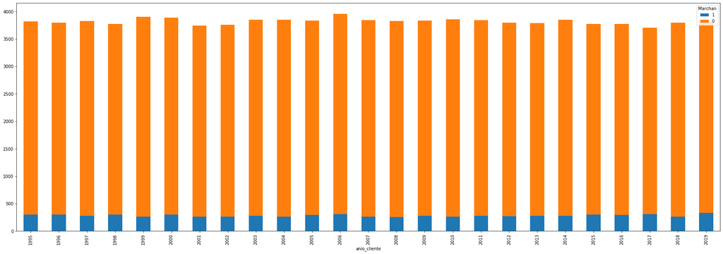

```python
data_diciembre_contarget.groupby(["anio_cliente", "Marchan"]).size().unstack().plot(kind='bar', stacked=True, figsize=(30,10))
```

### Muestreo de los datos.

```python
data_diciembre_contarget['Marchan'].value_counts()
```

```
0    88382
1     7085
Name: Marchan, dtype: int64
```

```python
#Cambiamos el formato de nuestra variable objetivo
data_diciembre_contarget ['Marchan'] = data_diciembre_contarget ['Marchan'].astype(int)
```

```python
Marchan_diciembre = data_diciembre_contarget['Marchan'] #solo me quedo con la veriable objetivo.
```

```python
data_diciembre_contarget2 = data_diciembre_contarget.copy()
```

```python
#data_diciembre_contarget.drop('Marchan',axis=1, inplace=True)
```

Elimiino la variable objetivo y las dummies realizadas para evitar la multicolinealidad.

```python
borrar = ['Marchan','num_dt_0.0','TV_tv-total']
for i in borrar:
    data_diciembre_contarget.drop(i, axis=1, inplace=True)
```

```python
datos = data_diciembre_contarget
```

```python
datos.shape
```

```
(95467, 25)
```

```python
datos.dtypes
```

```
id                  int64
edad                int64
facturacion         int64
provincia           int64
num_lineas          int64
incidencia          int64
num_llamad_ent      int64
num_llamad_sal      int64
mb_datos            int64
seg_llamad_ent      int64
seg_llamad_sal      int64
financiacion        int64
imp_financ          int32
descuentos          int64
conexion            Int64
vel_conexion        Int64
num_dt_1.0          uint8
num_dt_2.0          uint8
num_dt_3.0          uint8
num_dt_4.0          uint8
TV_Sin_tv           uint8
TV_tv-familiar      uint8
TV_tv-futbol        uint8
anio_cliente        int64
antiguedad_anios    int64
dtype: object
```

```python
Marchan_diciembre
```

```
0        0
1        0
2        0
3        0
4        1
        ..
95462    0
95463    0
95464    0
95465    0
95466    0
Name: Marchan, Length: 95467, dtype: int32
```

```python
X_train, X_test, Y_train, Y_test = train_test_split(datos,
                                                    Marchan_diciembre,
                                                    test_size=0.2,
                                                    random_state=42)
                                                    #stratify = Marchan_diciembre)
```

```python
len(X_train)
```

```
76373
```

```python
len(Y_train)
```

```
76373
```

```python
len(X_test)
```

```
19094
```

```python
len(Y_test)
```

```
19094
```

```python
Y_train.value_counts()
```

```
0    70734
1     5639
Name: Marchan, dtype: int64
```

# Contruir un modelo analitico de decision.

### Regresion Logistica

#### Dada la naturaleza de la variable objetivo, cuyos valores varian entre 0 y 1, es preciso la eleccion de una regresion de tipo logistica.

```python
classifier = LogisticRegression().fit(X_train, Y_train) #max_iter = 100 #solver = 'lbfgs', max_iter=1000
y_pred     = classifier.predict(X_test)
```

```python
classifier = LogisticRegression()
classifier.fit(X_train, Y_train)
```

```
LogisticRegression(C=1.0, class_weight=None, dual=False, fit_intercept=True,
                   intercept_scaling=1, l1_ratio=None, max_iter=100,
                   multi_class='auto', n_jobs=None, penalty='l2',
                   random_state=None, solver='lbfgs', tol=0.0001, verbose=0,
                   warm_start=False)
```

```python
y_pred = classifier.predict(X_test)
```

```
matriz de confusión
[[17648     0]
 [ 1446     0]]
accuracy
0.9242694040012569
precision
0.0
recall
0.0
f1
0.0
AUC
0.5
```

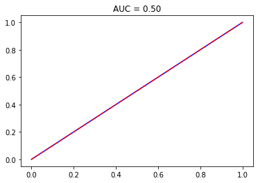

```python
saca_metricas(Y_test, y_pred)
```

Por las caracteristicas de la curva ROC es necesario realizar un reescalado de variables. Por lo que se puede observar en la matriz de confusion, la prediccion de 1 (exito: que abandonen la telefonica) es cero. Se trata de una clasificacion totalmente aleatoria, no hay puntos a la izquierda del espacio ROC.

### REESCALADO

```python
from sklearn.preprocessing import StandardScaler
sc =  StandardScaler()
datos_escalado = sc.fit_transform(datos)
```

```python
datos_escalado[0]
```

```
array([-1.73149667,  0.58894721,  0.08179969,  1.02443519,  1.32722316,
       -0.24079439, -0.20437622,  0.99510596, -0.22001817,  0.48959206,
        0.64565735, -0.26743067, -0.24076622, -0.50099164, -0.38016256,
       -0.31970149, -0.13269938, -0.13043347, -0.13212604, -0.13179737,
        0.58269247, -0.31456529, -0.37897055,  1.53223216, -1.53223216])
```

```python
datos_escalado.shape
```

```
(95467, 25)
```

```python
X_trainr, X_testr, Y_trainr, Y_testr = train_test_split(datos_escalado,
                                                    Marchan_diciembre,
                                                    test_size=0.2,
                                                    random_state=42)
                                                    #stratify = Marchan_diciembre)
```

```python
classifier = LogisticRegression().fit(X_trainr, Y_trainr) #max_iter = 100 #solver = 'lbfgs', max_iter=1000
y_pred     = classifier.predict(X_testr)
```

```python
classifier = LogisticRegression()
classifier.fit(X_trainr, Y_trainr)
```

```
LogisticRegression(C=1.0, class_weight=None, dual=False, fit_intercept=True,
                   intercept_scaling=1, l1_ratio=None, max_iter=100,
                   multi_class='auto', n_jobs=None, penalty='l2',
                   random_state=None, solver='lbfgs', tol=0.0001, verbose=0,
                   warm_start=False)
```

```python
y_predr = classifier.predict(X_testr)
```

```
matriz de confusión
[[17351   297]
 [   10  1436]]
accuracy
0.9839216507803499
precision
0.8286208886324293
recall
0.9930843706777317
f1
0.9034287511796163
AUC
0.988127634114931
```

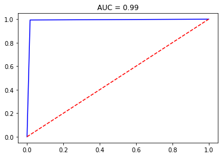

```python
saca_metricas(Y_testr, y_predr)
```

Como se puede observar, realizado el reescalado, se obtienen un resultado mas concistente con lo que se espera de un modelo. Acertada decision de realizar un reescalado de variables. Se observa el aumento de la precision, los casos de exito que efectivamente son exito, sobre los casos de exito previstos totales. Asi como mejora la curva ROC, entendida como el area entre la curva ROC y la linea de covexo-paralela discriminacion.En otras palabras, pasamos de u AUC=0.50,a un AUC=0.99.

### Arboles de desicion

```python
dt_classifier = DecisionTreeClassifier().fit(X_train, Y_train)
y_pred        = dt_classifier.predict(X_test)#Le pase OTRO conjunto de datos.
```

```
matriz de confusión
[[17413   235]
 [  291  1155]]
accuracy
0.9724520791871792
precision
0.8309352517985612
recall
0.7987551867219918
f1
0.8145275035260933
AUC
0.8927196151198353
```

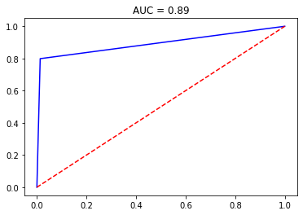

```python
saca_metricas(Y_test, y_pred)
```

### Random forest

```
matriz de confusión
[[17353   295]
 [   12  1434]]
accuracy
0.9839216507803499
precision
0.8293811451706189
recall
0.991701244813278
f1
0.9033070866141732
AUC
0.9874927348273099
```

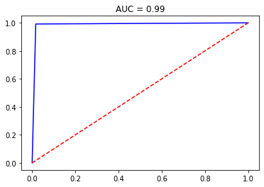

```python
rf_classifier = RandomForestClassifier().fit(X_train, Y_train) #n_estimadores (en la ayuda) significa cuantos desision trees vas a querer tener.
#Por defecto son 10 arboles de desision.
y_pred        = rf_classifier.predict(X_test)
saca_metricas(Y_test, y_pred)
```

Las metricas del modelo en terminos generales son buenas, casi tan buenas como el modelo logistico reescalado Con max_depth = none, se obtienen mejores resultados que asignandole algun valor como se puede ver en el proximo ejemplo.

```
matriz de confusión
[[17509   139]
 [  765   681]]
accuracy
0.9526552843825286
precision
0.8304878048780487
recall
0.470954356846473
f1
0.6010591350397175
AUC
0.731539055123146
```

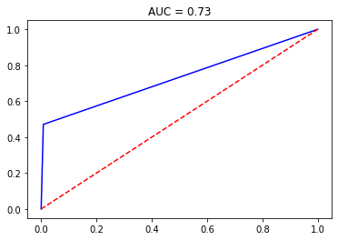

```python
dt_classifier = RandomForestClassifier(max_depth = 4).fit(X_train, Y_train)
# si mas_depth aumenta tambein tambien el accuracy.
y_pred        = dt_classifier.predict(X_test)
saca_metricas(Y_test, y_pred)
```

## BAGGING

```
matriz de confusión
[[17648     0]
 [ 1446     0]]
accuracy
0.9242694040012569
precision
0.0
recall
0.0
f1
0.0
AUC
0.5
```

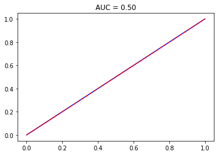

```python
#Con los datos reescalados.
model2 = RandomForestClassifier(max_depth=2, random_state=0)
model2.fit(X_trainr, Y_trainr)

y_predB = model2.predict(X_testr)
saca_metricas(Y_testr, y_predB)
```

El modelo presenta un recall cero, los casos de exito efectivamente predichos como exito son muy bajos respecto a los exitos efectivos. El modelo de regresion logistica reescalado presenta mejores indicadores.

### Evaluacion de variables mediante graficos.

```python
from matplotlib import pyplot
```

```
Feature: 0, Score: -0.01818
Feature: 1, Score: -0.01060
Feature: 2, Score: 0.02770
Feature: 3, Score: 0.03920
Feature: 4, Score: 0.02874
Feature: 5, Score: 1.79872
Feature: 6, Score: 0.00780
Feature: 7, Score: 0.02493
Feature: 8, Score: 0.03743
Feature: 9, Score: 0.01481
Feature: 10, Score: -0.01734
Feature: 11, Score: 0.07299
Feature: 12, Score: -0.54565
Feature: 13, Score: -1.51163
Feature: 14, Score: -0.16661
Feature: 15, Score: 0.31213
Feature: 16, Score: 1.03698
Feature: 17, Score: 0.99286
Feature: 18, Score: 1.02579
Feature: 19, Score: 1.02081
Feature: 20, Score: 2.99807
Feature: 21, Score: -0.33662
Feature: 22, Score: -0.58704
Feature: 23, Score: 0.00225
Feature: 24, Score: -0.00225
```

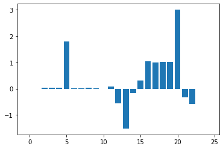

```python
#Obtener la importancias.
importancia = classifier.coef_[0]
# summarize feature importance
for i,v in enumerate(importancia):
	print('Feature: %0d, Score: %.5f' % (i,v))
# plot feature importance
pyplot.bar([x for x in range(len(importancia))], importancia)
pyplot.show()
```

Los scores positivos indican un resultado que predice de class 1, mientras que los negativos indican un resultado que predice class 0.

#### valor VIF:

Vamos a calcular el valor del VIF para todas las variables menos la objetivo. Para esto se realiza una regresión lineal de cada una de las variables frente al resto y aplicamos la fórmula del VIF

```python
from sklearn.linear_model import LinearRegression

# Borrado de la variable objetivo
data_vif = data_diciembre_contarget2#(deep = True)
features = list(data_vif.columns)
features.remove('Marchan')
data_vif = data_vif[features]

for i in range(len(features)): #BUCLE: PARA IR RECORRIENDO TODAS LAS VARIABLES.
    var = features[i]
    fet = features[:]
    fet.remove(var)

    x = data_vif[fet]
    y = data_diciembre_contarget2[var]

    model = LinearRegression()
    model.fit(x, y)

    vif = 1 / (1 - model.score(x, y))

    print ('El valor del VIF para la variable', var, 'es:', vif)
```

```
El valor del VIF para la variable id es: 1.0001114986361086
El valor del VIF para la variable edad es: 1.0003031907485904
El valor del VIF para la variable facturacion es: 1.36552354846097
El valor del VIF para la variable provincia es: 1.0003713368474036
El valor del VIF para la variable num_lineas es: 1.2815260397863901
El valor del VIF para la variable incidencia es: 1.0001499978207922
El valor del VIF para la variable num_llamad_ent es: 1.00025083286865
El valor del VIF para la variable num_llamad_sal es: 1.0001297895520085
El valor del VIF para la variable mb_datos es: 1.0002227575511926
El valor del VIF para la variable seg_llamad_ent es: 1.000252159343022
El valor del VIF para la variable seg_llamad_sal es: 1.0002260226013113
El valor del VIF para la variable financiacion es: 8.945496610309487
El valor del VIF para la variable imp_financ es: 5.283373567732698
El valor del VIF para la variable descuentos es: 14.573016568573205
El valor del VIF para la variable conexion es: 2.9202415450056143
El valor del VIF para la variable vel_conexion es: 2.3989431478537253
```

```
El valor del VIF para la variable num_dt_0.0 es: inf
```

```
El valor del VIF para la variable num_dt_1.0 es: inf
```

```
El valor del VIF para la variable num_dt_2.0 es: inf
```

```
El valor del VIF para la variable num_dt_3.0 es: inf
```

```
El valor del VIF para la variable num_dt_4.0 es: inf
```

```
El valor del VIF para la variable TV_Sin_tv es: inf
```

```
El valor del VIF para la variable TV_tv-familiar es: inf
```

```
El valor del VIF para la variable TV_tv-futbol es: inf
```

```
El valor del VIF para la variable TV_tv-total es: inf
```

```
El valor del VIF para la variable anio_cliente es: inf
El valor del VIF para la variable antiguedad_anios es: inf
```

### 5. Mejora de modelos

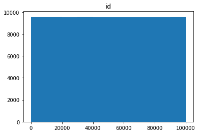

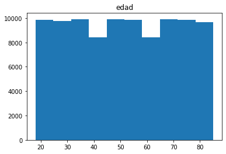

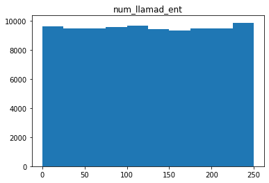

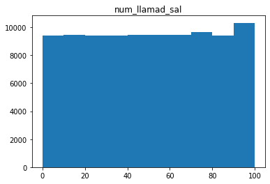

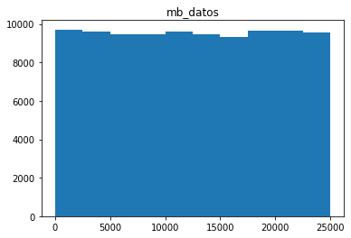

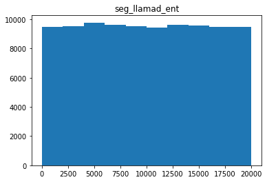

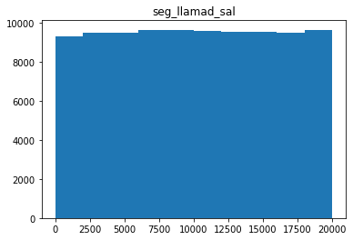

```python
for l in lista_numerica:
    plt.hist(data_diciembre_contarget[l])
    plt.title(l)
    plt.show()
```

### correlaccion de variables:

```python
corr = abs(data_diciembre_contarget2.corr()) #MIRA LA VARIABLEQUE ESTE MAS CRRELACIONADA CON LA Y
corr[['Marchan']].sort_values(by = 'Marchan',ascending = False).style.background_gradient()
```

|  | Marchan |
| --- | --- |
| Marchan | 1.000000 |
| num_dt_0.0 | 0.560509 |
| incidencia | 0.500885 |
| num_dt_1.0 | 0.281444 |
| num_dt_3.0 | 0.274326 |
| num_dt_2.0 | 0.268741 |
| num_dt_4.0 | 0.266841 |
| TV_Sin_tv | 0.164060 |
| descuentos | 0.141447 |
| conexion | 0.106914 |
| TV_tv-futbol | 0.106816 |
| vel_conexion | 0.089767 |
| TV_tv-familiar | 0.088505 |
| financiacion | 0.074597 |
| imp_financ | 0.067354 |
| TV_tv-total | 0.055734 |
| num_llamad_ent | 0.006130 |
| antiguedad_anios | 0.003310 |
| anio_cliente | 0.003310 |
| num_llamad_sal | 0.003141 |
| edad | 0.002864 |
| facturacion | 0.002857 |
| num_lineas | 0.001733 |
| mb_datos | 0.001201 |
| id | 0.000866 |
| seg_llamad_ent | 0.000526 |
| provincia | 0.000143 |
| seg_llamad_sal | 0.000089 |

### Feature Engineering

```python
def proporciones_final (var,target,df):

    proporcion = pd.DataFrame()

    proporcion['%depositos'] = df[target].groupby(df[var]).mean()*100
    proporcion['Conteo'] = df[target].groupby(df[var]).count()
    proporcion= proporcion.round(3)
    proporcion_filtered = proporcion[(proporcion['%depositos']>0) & (proporcion['Conteo']>10)]

    if len(proporcion_filtered)<100 and len(proporcion_filtered)>1:
        fig = plt.figure()
        ax = proporcion_filtered['Conteo'].plot(kind='bar',grid=True)

        ax2 = ax.twinx()
        ax2.plot(proporcion_filtered['%depositos'].values, linestyle='-', linewidth=2.0,color='g')
        plt.tight_layout()

    #else:
       # proporcion_filtered.reset_index(inplace=True)
       # sns.lmplot(x = var,y ='%depositos',data=proporcion_filtered, fit_reg=True,ci=None)
```

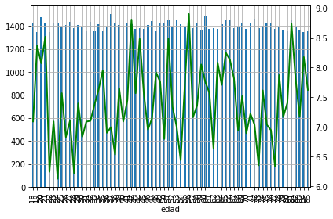

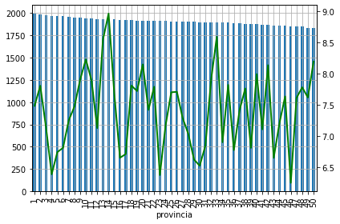

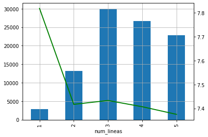

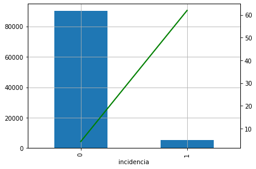

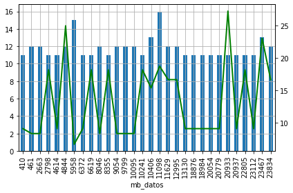

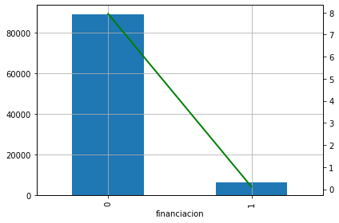

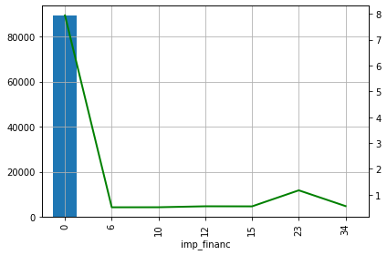

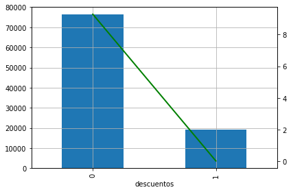

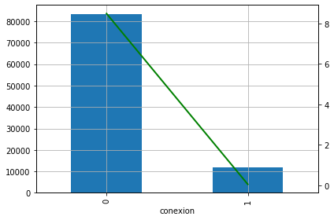

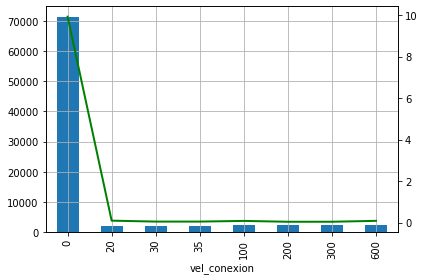

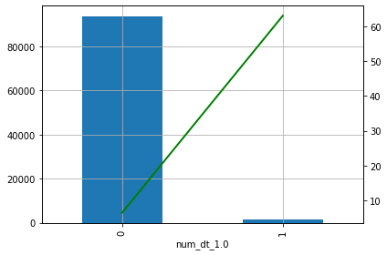

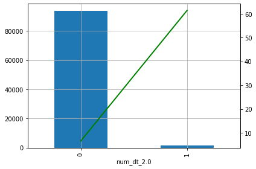

[7 more figures not shown]

```python
for i in datos.columns: #HAY WARRININGS PERO LOS GRAFICOS SE VEN MAS ABAJO.
    proporciones_final (i, 'Marchan', data_diciembre_contarget2)
```

##### Seleccion de variables.

```python
from sklearn.feature_selection import chi2
```

```python
from sklearn.feature_selection import SelectKBest
```

```python
S_chi5 = SelectKBest(chi2, k = 20)
X_chi5 = S_chi5.fit_transform(data_diciembre_contarget2, data_diciembre_contarget2['Marchan'])

variables = list(np.asarray(list(data_diciembre_contarget2))[S_chi5.get_support()])
variables.sort()
print(variables)
```

```
['Marchan', 'TV_Sin_tv', 'TV_tv-familiar', 'TV_tv-futbol', 'TV_tv-total', 'conexion', 'descuentos', 'financiacion', 'id', 'imp_financ', 'incidencia', 'mb_datos', 'num_dt_0.0', 'num_dt_1.0', 'num_dt_2.0', 'num_dt_3.0', 'num_dt_4.0', 'num_llamad_ent', 'seg_llamad_ent', 'vel_conexion']
```

```python
seleccionchi2 = ['Marchan', 'TV_tv-familiar', 'TV_tv-futbol', 'TV_tv-total', 'conexion', 'descuentos', 'facturacion', 'financiacion', 'id', 'imp_financ', 'incidencia', 'mb_datos', 'num_dt_0.0', 'num_dt_1.0', 'num_dt_2.0', 'num_dt_3.0', 'num_dt_4.0', 'num_llamad_ent', 'seg_llamad_ent', 'vel_conexion']
```

```python
### Mejoro el modelo.
```

```python
## antiguedad anios (realizamos una variable con 3 rangos de edad y 3 variables con esos mismos rangos)
#df_bank['antiguedad_reciente'] = df_bank['antiguedad_anios'].apply(lambda x: 1 if x<=13 else 0)
#df_bank['antiguedad_consolidado'] = df_bank['antiguedad_anios'].apply(lambda x: 1 if x>13 else 0)
datos['antiguedad_tramos'] = datos['antiguedad_anios'].apply(lambda x: 0 if x<=13 else (1 if x>13 else 0))
```

```python
datos
```

|  | id | edad | facturacion | provincia | num_lineas | incidencia | num_llamad_ent | num_llamad_sal | mb_datos | seg_llamad_ent | ... | num_dt_1.0 | num_dt_2.0 | num_dt_3.0 | num_dt_4.0 | TV_Sin_tv | TV_tv-familiar | TV_tv-futbol | anio_cliente | antiguedad_anios | antiguedad_tramos |
| --- | --- | --- | --- | --- | --- | --- | --- | --- | --- | --- | --- | --- | --- | --- | --- | --- | --- | --- | --- | --- | --- |
| 0 | 1 | 63 | 216 | 40 | 5 | 0 | 110 | 79 | 10897 | 12806 | ... | 0 | 0 | 0 | 0 | 1 | 0 | 0 | 2018 | 1 | 0 |
| 1 | 2 | 84 | 255 | 49 | 3 | 0 | 189 | 89 | 18657 | 6499 | ... | 0 | 0 | 0 | 0 | 0 | 0 | 1 | 2017 | 2 | 0 |
| 2 | 3 | 66 | 135 | 36 | 4 | 0 | 129 | 30 | 15511 | 17013 | ... | 0 | 0 | 0 | 0 | 0 | 0 | 1 | 2001 | 18 | 1 |
| 3 | 4 | 69 | 255 | 41 | 4 | 0 | 51 | 52 | 12670 | 3393 | ... | 0 | 0 | 0 | 0 | 1 | 0 | 0 | 2015 | 4 | 0 |
| 4 | 5 | 25 | 22 | 22 | 2 | 0 | 183 | 3 | 23756 | 18436 | ... | 0 | 1 | 0 | 0 | 1 | 0 | 0 | 1997 | 22 | 1 |
| ... | ... | ... | ... | ... | ... | ... | ... | ... | ... | ... | ... | ... | ... | ... | ... | ... | ... | ... | ... | ... | ... |
| 95462 | 99995 | 65 | 173 | 6 | 5 | 0 | 121 | 98 | 13403 | 6197 | ... | 0 | 0 | 0 | 0 | 0 | 1 | 0 | 2019 | 0 | 0 |
| 95463 | 99996 | 36 | 215 | 38 | 3 | 0 | 98 | 13 | 5291 | 3684 | ... | 0 | 0 | 0 | 0 | 1 | 0 | 0 | 2013 | 6 | 0 |
| 95464 | 99997 | 68 | 285 | 4 | 5 | 0 | 226 | 20 | 20002 | 572 | ... | 0 | 0 | 0 | 0 | 0 | 0 | 1 | 2003 | 16 | 1 |
| 95465 | 99998 | 20 | 383 | 13 | 4 | 0 | 126 | 26 | 16448 | 833 | ... | 0 | 0 | 0 | 0 | 1 | 0 | 0 | 2013 | 6 | 0 |
| 95466 | 100000 | 18 | 57 | 45 | 4 | 0 | 85 | 25 | 17933 | 18617 | ... | 0 | 0 | 0 | 0 | 0 | 1 | 0 | 2009 | 10 | 0 |

95467 rows × 26 columns

Me copio un data set para mejorar el modelo (datos2), voy a quitar varias variables. Entre ellas antiguedad_anios ya que la sustituire por antiguedad_tramos

```python
datos2 = datos
```

```python
borrar = ['seg_llamad_sal','provincia','seg_llamad_ent','edad','num_llamad_sal','anio_cliente','mb_datos','antiguedad_anios','facturacion',]
for i in borrar:
    datos2.drop(i, axis=1, inplace=True)
```

```python
datos_escalado2 = sc.fit_transform(datos2)
```

```python
X_trainr2, X_testr2, Y_trainr2, Y_testr2 = train_test_split(datos_escalado2,
                                                    Marchan_diciembre,
                                                    test_size=0.2,
                                                    random_state=42)
                                                    #stratify = Marchan_diciembre)
```

```python
classifier = LogisticRegression().fit(X_trainr2, Y_trainr2) #max_iter = 100 #solver = 'lbfgs', max_iter=1000
```

```python
y_predr2 = classifier.predict(X_testr2)
```

```
matriz de confusión
[[17351   297]
 [   10  1436]]
accuracy
0.9839216507803499
precision
0.8286208886324293
recall
0.9930843706777317
f1
0.9034287511796163
AUC
0.988127634114931
```

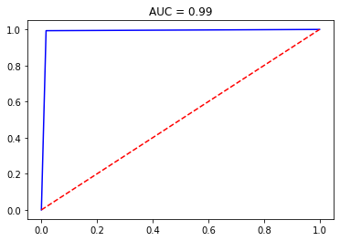

```python
saca_metricas(Y_testr2, y_predr2)
```

```python
datos2.shape
```

```
(95467, 17)
```

Como se puede observar el poder explicativo del modelo permanece constante pero se gana en parsimonia, menor cantidad de variables, y simplicidad del modelo.

```python
datos2.dtypes
```

```
id                   int64
num_lineas           int64
incidencia           int64
num_llamad_ent       int64
financiacion         int64
imp_financ           int32
descuentos           int64
conexion             Int64
vel_conexion         Int64
num_dt_1.0           uint8
num_dt_2.0           uint8
num_dt_3.0           uint8
num_dt_4.0           uint8
TV_Sin_tv            uint8
TV_tv-familiar       uint8
TV_tv-futbol         uint8
antiguedad_tramos    int64
dtype: object
```

```python
print(classifier)
```

```
LogisticRegression(C=1.0, class_weight=None, dual=False, fit_intercept=True,
                   intercept_scaling=1, l1_ratio=None, max_iter=100,
                   multi_class='auto', n_jobs=None, penalty='l2',
                   random_state=None, solver='lbfgs', tol=0.0001, verbose=0,
                   warm_start=False)
```

```python
classifier.coef_
```

```
array([[-0.01956523,  0.03547809,  1.79311042,  0.00733914,  0.07838479,
        -0.51837566, -1.51833247, -0.18776092,  0.31254383,  1.03389269,
         0.99018167,  1.02309698,  1.0183393 ,  2.96801291, -0.37528806,
        -0.55139578,  0.00344475]])
```

```python
print('R2 en entrenamiento es:', classifier.score(X_trainr2,Y_trainr2))
print('R2 en validacion es: ', classifier.score(X_testr2,Y_testr2))
```

```
R2 en entrenamiento es: 0.9836460529244628
R2 en validacion es:  0.9839216507803499
```

OTROS MODELOS

```python
X_train3, X_testr3, Y_trainr3, Y_testr3 = train_test_split(datos2,
                                                    Marchan_diciembre,
                                                    test_size=0.2,
                                                    random_state=42)
                                                    #stratify = Marchan_diciembre)
```

```
matriz de confusión
[[17364   284]
 [   75  1371]]
accuracy
0.9811982821828846
precision
0.8283987915407856
recall
0.9481327800829875
f1
0.8842308932602386
AUC
0.9660201525074955
```

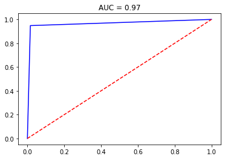

```python
rf_classifier = RandomForestClassifier().fit(X_train3, Y_trainr3) #n_estimadores (en la ayuda) significa cuantos desision trees vas a querer tener.
#Por defecto son 10 arboles de desision.
y_pred        = rf_classifier.predict(X_testr3)
saca_metricas(Y_testr3, y_pred)
```

Este modelo queda descartado ya que dio un peor resultado.

### 6. predecir los clientes de la cosecha de Enero.

```python
#hacemos un modelo con los datos de diciembre y lo cargamos
```

###### Podemos guardar el modelo como un objeto de python (pickle) para después volver a usarlo para predecir futuros datos...

```python
data_enero.shape
```

```
(92711, 25)
```

```python
datos.dtypes
```

```
id                   int64
num_lineas           int64
incidencia           int64
num_llamad_ent       int64
financiacion         int64
imp_financ           int32
descuentos           int64
conexion             Int64
vel_conexion         Int64
num_dt_1.0           uint8
num_dt_2.0           uint8
num_dt_3.0           uint8
num_dt_4.0           uint8
TV_Sin_tv            uint8
TV_tv-familiar       uint8
TV_tv-futbol         uint8
antiguedad_tramos    int64
dtype: object
```

```python
data_enero.dtypes
```

[output not shown]

```python
data_enero['antiguedad_tramos'] = data_enero['antiguedad_anios'].apply(lambda x: 0 if x<=13 else (1 if x>13 else 0))
```

```python
borrar = ['seg_llamad_sal','provincia','seg_llamad_ent','edad','num_llamad_sal','anio_cliente','mb_datos','antiguedad_anios','facturacion',]
for i in borrar:
    data_enero.drop(i, axis=1, inplace=True)
```

```python
data_enero.shape
```

```
(92711, 17)
```

```python
datos.shape
```

```
(95467, 17)
```

```python
X_testr2.shape
```

```
(19094, 17)
```

```python
X_trainr2.shape
```

```
(76373, 17)
```

```python
from sklearn.preprocessing import StandardScaler
sc =  StandardScaler()
data_eneroEsc = sc.fit_transform(data_enero)
```

```python
data_eneroEsc
```

```
array([[-1.732205  ,  1.32600859, -0.14814401, ..., -0.32835519,
        -0.39564007, -0.92143512],
       [-1.73217035, -0.51594374, -0.14814401, ..., -0.32835519,
         2.52754983, -0.92143512],
       [-1.7321357 ,  0.40503242, -0.14814401, ..., -0.32835519,
         2.52754983,  1.0852636 ],
       ...,
       [ 1.73233502,  0.40503242, -0.14814401, ..., -0.32835519,
        -0.39564007, -0.92143512],
       [ 1.73236966, -1.4369199 , -0.14814401, ..., -0.32835519,
        -0.39564007, -0.92143512],
       [ 1.73240431,  0.40503242, -0.14814401, ...,  3.04548255,
        -0.39564007, -0.92143512]])
```

```python
import pickle
```

```python
pkl_filename = "modelo1.pkl"
with open(pkl_filename, 'wb') as file:
    pickle.dump(classifier, file)

# Load from file
with open(pkl_filename, 'rb') as file:
    pickle_model = pickle.load(file)

# Calculate the accuracy score and predict target values
score = pickle_model.score(X_testr2, Y_testr2)
print("Test score: {0:.2f} %".format(100 * score))
Ypredict = pickle_model.predict(X_testr2)
```

```
Test score: 98.39 %
```

Para saber que clientes tienen mayor probabilidad de contratar. Realizo el modelo Proba.

```python
modelo_proba = classifier.predict_proba(data_enero)[:,1]
modelo_proba = (pd.DataFrame(modelo_proba,columns=['probabilidad'],index= data_enero.index))
modelo_proba.sort_values(by=['probabilidad'],ascending=False,axis=0,inplace=True)
```

```python
modelo_proba.head()
```

|  | probabilidad |
| --- | --- |
| 240 | 1.0 |
| 2222 | 1.0 |
| 2147 | 1.0 |
| 2155 | 1.0 |
| 2182 | 1.0 |

```python
modelo_proba.sum
```

```
<bound method DataFrame.sum of        probabilidad
240             1.0
2222            1.0
2147            1.0
2155            1.0
2182            1.0
...             ...
53488           0.0
53489           0.0
53490           0.0
53491           0.0
92710           0.0

[92711 rows x 1 columns]>
```

```python
modelo_proba.dtypes
```

```
probabilidad    float64
dtype: object
```

```python
modelo_proba['probabilidad'] = modelo_proba['probabilidad'].astype(int)
```

```python
modelo_proba['probabilidad'].value_counts()
```

```
0    92452
1      259
Name: probabilidad, dtype: int64
```

### 7. Obtener y explicar las claves (a través de las variables) de la marcha de los clientes en la compañía.

Si tuvo una incedencia, si el usuario no tiene servicio de TV contratada respecto al tener el servicio completo, si el usuario tuvo alguna incidencia respecto al que no tuvo, el tener algun lina en impago respecto a no tenerla impacta positivamente y de forma pronunciada en la fuga de clientes. Tambien pero en menor grado, a mayor numero de lineas contratadas, numero de llamadas entrantes de todas sus lineas, si el cliente esta financiando alguna terminal, velocidad de conexion y la antiguedad cuanto es mayor, mas probable que abandone el servicio. Por otro lado aquellas variables que mas impactan en la retencion de clientes son, que tenga contratado el servicio de futbol o la television familiar (presumbilemente servicios de caracter inelastico/retenedores de clientes), el monto que paga, si le ralizan algun descuento y si tiene Fibra contratada (un servicio de mayor calidad que el ADSL).

El Modelo elegido predice (clasifica como baja de clientes) que se iran de la compania 259 clientes. Mediante esta informacion, es posible establecer politicas de retencion al cliente si durante el transito de mes, con el objetivo de retener al cliente. Es especialmente importante lograr la retencion, ya que segun lo visto en el master, captar un nuevo cliente es mucho mas costoso que retner el que ya lo es. Un ejemplo podria ser ofrecer servicios de TV a los que no tienen con algun tipo de descuento.